# Домашняя работа № 9, Плеханов Антон 316

**Обновленная реализация функции regr()**

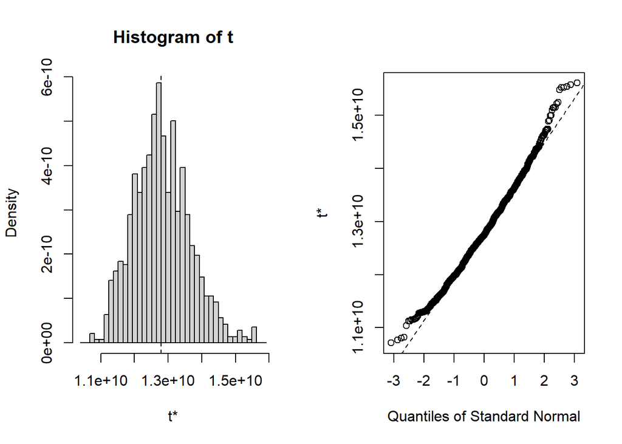

```r
# Модель для оценки постоянной Хаббла
library(gamair)
data(hubble)

M <- lm(y ~ x - 1, data = hubble) # "-1" - для исключения свободного члена

# Оценим возраст Вселенной "вручную"
hub.const <- summary(M)$coefficients[1] /3.09e19
age <- (1/hub.const)/(60^2*24*365)

# Модифицированная функция regr, возвращающая возраст вселенной
regr <- function(data, indices) {
  # вектор indices будет формироваться функцией boot()
  dat <- data[indices, ]
  fit <- lm(y ~ -1 + x, data = dat)
  # return(summary(fit)$coefficients[1])
  return ((1 / (summary(fit)$coefficients[1] / 3.09e19)) / (60^2 * 24 * 365))
}

library(boot)
results <- boot(data = hubble, statistic = regr, R = 1000)

plot(results)
```

```r
print("Возраст вселенной, оцененный по всей выборке: ")
```

```
## [1] "Возраст вселенной, оцененный по всей выборке: "
```

```r
print(age)
```

```
## [1] 12794692825
```

Загрузка данных:

```r
file <- file.choose()
data <- read.csv(file)
str(data)
```

```
## 'data.frame':    12181 obs. of  22 variables:
##  $ price                : int  8000000 7200000 10300000 8500000 9000000 8050000 10900000 8100000 10000000 9000000 ...
##  $ repair               : int  3 2 2 2 2 2 2 2 3 3 ...
##  $ year_built_empty     : int  0 0 0 0 0 0 0 0 0 0 ...
##  $ house_age            : int  42 43 43 43 43 38 35 32 45 44 ...
##  $ closest_subway       : int  59 59 59 59 59 59 59 59 59 59 ...
##  $ dist_to_subway       : int  960 802 638 929 785 962 556 859 1323 796 ...
##  $ sg                   : num  0 0 0 0 0 0 0 0 0 0 ...
##  $ lat                  : num  55.6 55.6 55.6 55.6 55.6 ...
##  $ lon                  : num  37.7 37.7 37.7 37.7 37.7 ...
##  $ subway_dist_to_center: int  17166 17166 17166 17166 17166 17166 17166 17166 17166 17166 ...
##  $ h3                   : chr  "861181b6fffffff" "861181b4fffffff" "861181b4fffffff" "861181b6fffffff" ...
##  $ agent_offers         : int  1 1 57 292 292 292 57 36 65 1 ...
##  $ subway_offers        : int  5 9 9 5 5 5 9 13 6 9 ...
##  $ address_offers       : num  1 1 2 1 1 1 1 1 1 1 ...
##  $ rooms                : int  1 1 2 2 2 1 2 1 2 2 ...
##  $ footage              : num  39.4 35.6 53 44.1 44.2 39.5 57 33.9 45.9 45.8 ...
##  $ floor                : int  11 2 5 8 6 1 19 2 10 6 ...
##  $ max_floor            : int  12 9 12 9 9 12 22 22 12 12 ...
##  $ first_floor          : int  0 0 0 0 0 1 0 0 0 0 ...
##  $ last_floor           : int  0 0 0 0 0 0 0 0 0 0 ...
##  $ AO                   : chr  "UAO" "UAO" "UAO" "UAO" ...
##  $ hm                   : chr  "panel" "panel" "panel" "panel" ...
```

Целевая переменная - price. Для построения регрессионной модели будем использовать следующие признаки (их будет несколько, т.е. модель будет множественной. В конкретной задаче нет смысла рассматривать другую модель, это будет показано в пункте 3):

```r
features <- c("price", "repair", "year_built_empty", "house_age",
              "dist_to_subway", "subway_dist_to_center",
              "rooms", "footage", "floor", "AO", "hm",
              "first_floor", "last_floor")

data <- data[, features]
colnames(data)
```

```
##  [1] "price"                 "repair"                "year_built_empty"
##  [4] "house_age"             "dist_to_subway"        "subway_dist_to_center"
##  [7] "rooms"                 "footage"               "floor"
## [10] "AO"                    "hm"                    "first_floor"
## [13] "last_floor"
```

Также преобразуем категориальные признаки к типу factor:

```r
categorical <- c("AO", "hm", "first_floor", "last_floor")

for (feature in categorical) {
  data[, feature] <- as.factor(data[, feature])
}
```

Напомним распределение признака price (чтобы понимать масштабы ошибок):

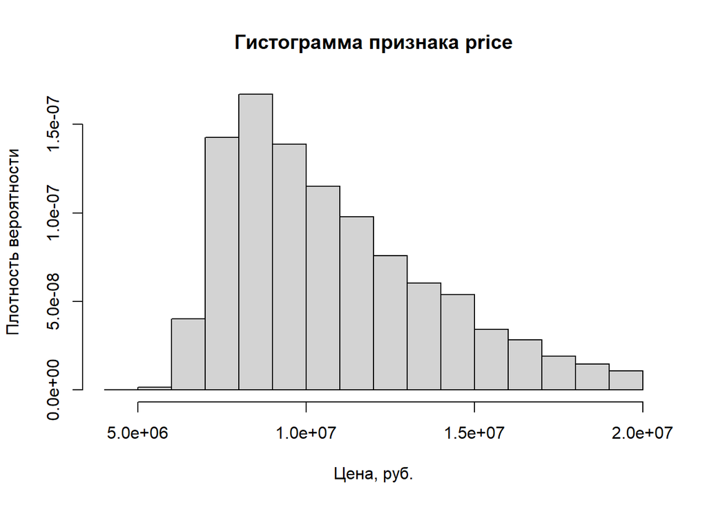

```r
hist(data$price, freq = FALSE, main="Гистограмма признака price",
     xlab = "Цена, руб.", ylab = "Плотность вероятности")
```

Построение регрессионной модели:

```r
M <- lm(price ~ repair + year_built_empty + house_age + dist_to_subway +
          subway_dist_to_center + rooms + footage + floor + AO +
          hm + first_floor + last_floor,
        data = data
          )
summary(M)
```

```
##
## Call:
## lm(formula = price ~ repair + year_built_empty + house_age +
##     dist_to_subway + subway_dist_to_center + rooms + footage +
##     floor + AO + hm + first_floor + last_floor, data = data)
##
## Residuals:
##      Min       1Q   Median       3Q      Max
## -7007725  -821675   -93284   681873  7050752
##
## Coefficients:
##                         Estimate Std. Error t value Pr(>|t|)
## (Intercept)            7.013e+06  1.075e+05  65.211  < 2e-16 ***
## repair                 5.954e+05  1.490e+04  39.966  < 2e-16 ***
## year_built_empty       4.583e+05  1.022e+05   4.485 7.36e-06 ***
## house_age             -2.800e+04  8.920e+02 -31.388  < 2e-16 ***
## dist_to_subway        -5.526e+02  2.257e+01 -24.486  < 2e-16 ***
## subway_dist_to_center -2.932e+02  3.152e+00 -93.006  < 2e-16 ***
## rooms                  1.509e+04  3.565e+04   0.423 0.672138
## footage                1.751e+05  1.761e+03  99.429  < 2e-16 ***
## floor                  2.947e+04  2.743e+03  10.742  < 2e-16 ***
## AOSAO                 -8.491e+05  6.425e+04 -13.216  < 2e-16 ***
## AOSVAO                -1.124e+06  6.599e+04 -17.034  < 2e-16 ***
## AOSZAO                -2.494e+05  7.459e+04  -3.344 0.000829 ***
## AOUAO                 -9.713e+05  6.644e+04 -14.619  < 2e-16 ***
## AOUVAO                -2.384e+06  6.294e+04 -37.880  < 2e-16 ***
## AOUZAO                -3.710e+04  6.692e+04  -0.554 0.579358
## AOVAO                 -1.812e+06  6.560e+04 -27.626  < 2e-16 ***
## AOZAO                 -1.838e+05  6.472e+04  -2.840 0.004524 **
## hmbrick                5.062e+05  4.301e+04  11.771  < 2e-16 ***
## hmmonolith             8.209e+05  5.038e+04  16.296  < 2e-16 ***
## hmpanel                1.178e+05  3.935e+04   2.994 0.002755 **
## first_floor1          -6.686e+05  4.125e+04 -16.208  < 2e-16 ***
## last_floor1           -3.241e+05  4.237e+04  -7.650 2.17e-14 ***
## ---
## Signif. codes:  0 '***' 0.001 '**' 0.01 '*' 0.05 '.' 0.1 ' ' 1
##
## Residual standard error: 1286000 on 12159 degrees of freedom
## Multiple R-squared:  0.821,  Adjusted R-squared:  0.8207
## F-statistic:  2656 on 21 and 12159 DF,  p-value: < 2.2e-16
```

По коэффициентам модели можем сделать следующие наблюдения:

1. Поскольку в качестве базового уровня признака AO был выбран “CAO” (Центральный АО), коэффициенты, соответствующие другим АО, меньше нуля (то есть если квартира НЕ в CAO, то это уменьшает прогноз ее цены) - логично. При этом гипотеза о равенстве нулю коэффициента AOUZAO принимается (p-value = 0.57 > 0).
2. Квартиры на первых/последних этажах уменьшают прогноз цены (см. признаки first_floor1, last_floor1 и соответствующие коэффициенты).
3. Коэффициенты, соответствующие признакам hmbrick, hmmonolith, hmpanel больше нуля, т.е. в сравнении с базовым уровнем “block” эти признаки вносят положительный вклад в прогноз цены.
4. Веса, соответствующие признакам расстояния до метро/центра, а также возрасту дома, отрицательны, что правдоподобно.

Используем параметрический подход для построения доверительных интервалов для коэффициентов модели:

```r
out <- summary(M)
coef_est <- out$coefficients[, 1]
std_est <- out$coefficients[, 2]

free_deg <- out$df[2]

ci.lower <- coef_est - qt(0.975, df = free_deg) * std_est
ci.upper <- coef_est + qt(0.975, df = free_deg) * std_est

for (coef_name in rownames(out$coefficients)) {
  print(c(ci.lower[coef_name], ci.upper[coef_name]))
}
```

```
## (Intercept) (Intercept)
##     6801942     7223533
##   repair   repair
## 566234.2 624640.9
## year_built_empty year_built_empty
##         257997.2         658579.3
## house_age house_age
## -29747.41 -26250.35
## dist_to_subway dist_to_subway
##      -596.8771      -508.3973
## subway_dist_to_center subway_dist_to_center
##             -299.3471             -286.9897
##     rooms     rooms
## -54789.83  84964.81
##  footage  footage
## 171655.9 178560.1
##    floor    floor
## 24090.85 34845.65
##     AOSAO     AOSAO
## -975034.0 -723163.3
##     AOSVAO     AOSVAO
## -1253340.1  -994652.6
##    AOSZAO    AOSZAO
## -395600.7 -103199.6
##      AOUAO      AOUAO
## -1101484.7  -841021.2
##   AOUVAO   AOUVAO
## -2507602 -2260854
##     AOUZAO     AOUZAO
## -168272.34   94078.75
##    AOVAO    AOVAO
## -1940982 -1683792
##      AOZAO      AOZAO
## -310660.99  -56924.11
##  hmbrick  hmbrick
## 421911.9 590507.0
## hmmonolith hmmonolith
##   722188.9   919679.9
##   hmpanel   hmpanel
##  40703.79 194985.80
## first_floor1 first_floor1
##    -749404.2    -587700.2
## last_floor1 last_floor1
##   -407169.2   -241066.3
```

**Оценка качества регрессионных моделей**

Функция, извелкающая всю полезную для оценки качества модели информацию:

```r
extract <- function(fit) {
  sigma <- summary(fit)$sigma  # среднеквадратическаяя ошибка
  R2.adj <- summary(fit)$adj.r.squared  # скорректированный коэффициент R2
  aic <- AIC(fit)           #  Информационный АIC-критерий
  out <- data.frame(sigma = sigma, R2.adj = R2.adj, AIC = aic)
  return(out)    }
```

Рассмотрим еще несколько регрессионых моделей для рассматриваемых данных.

Базовая модель:

```r
M <- lm(price ~ repair + year_built_empty + house_age + dist_to_subway +
          subway_dist_to_center + rooms + footage + floor + AO +
          hm + first_floor + last_floor,
        data = data
          )
summary(M)
```

```
##
## Call:
## lm(formula = price ~ repair + year_built_empty + house_age +
##     dist_to_subway + subway_dist_to_center + rooms + footage +
##     floor + AO + hm + first_floor + last_floor, data = data)
##
## Residuals:
##      Min       1Q   Median       3Q      Max
## -7007725  -821675   -93284   681873  7050752
##
## Coefficients:
##                         Estimate Std. Error t value Pr(>|t|)
## (Intercept)            7.013e+06  1.075e+05  65.211  < 2e-16 ***
## repair                 5.954e+05  1.490e+04  39.966  < 2e-16 ***
## year_built_empty       4.583e+05  1.022e+05   4.485 7.36e-06 ***
## house_age             -2.800e+04  8.920e+02 -31.388  < 2e-16 ***
## dist_to_subway        -5.526e+02  2.257e+01 -24.486  < 2e-16 ***
## subway_dist_to_center -2.932e+02  3.152e+00 -93.006  < 2e-16 ***
## rooms                  1.509e+04  3.565e+04   0.423 0.672138
## footage                1.751e+05  1.761e+03  99.429  < 2e-16 ***
## floor                  2.947e+04  2.743e+03  10.742  < 2e-16 ***
## AOSAO                 -8.491e+05  6.425e+04 -13.216  < 2e-16 ***
## AOSVAO                -1.124e+06  6.599e+04 -17.034  < 2e-16 ***
## AOSZAO                -2.494e+05  7.459e+04  -3.344 0.000829 ***
## AOUAO                 -9.713e+05  6.644e+04 -14.619  < 2e-16 ***
## AOUVAO                -2.384e+06  6.294e+04 -37.880  < 2e-16 ***
## AOUZAO                -3.710e+04  6.692e+04  -0.554 0.579358
## AOVAO                 -1.812e+06  6.560e+04 -27.626  < 2e-16 ***
## AOZAO                 -1.838e+05  6.472e+04  -2.840 0.004524 **
## hmbrick                5.062e+05  4.301e+04  11.771  < 2e-16 ***
## hmmonolith             8.209e+05  5.038e+04  16.296  < 2e-16 ***
## hmpanel                1.178e+05  3.935e+04   2.994 0.002755 **
## first_floor1          -6.686e+05  4.125e+04 -16.208  < 2e-16 ***
## last_floor1           -3.241e+05  4.237e+04  -7.650 2.17e-14 ***
## ---
## Signif. codes:  0 '***' 0.001 '**' 0.01 '*' 0.05 '.' 0.1 ' ' 1
##
## Residual standard error: 1286000 on 12159 degrees of freedom
## Multiple R-squared:  0.821,  Adjusted R-squared:  0.8207
## F-statistic:  2656 on 21 and 12159 DF,  p-value: < 2.2e-16
```

Модель без признака rooms (поскольку p-value, соответствующее этому признаку, больше 0.05):

```r
M1 <- lm(price ~ repair + year_built_empty + house_age + dist_to_subway +
          subway_dist_to_center + footage + floor + AO +
          hm + first_floor + last_floor,
        data = data
          )
summary(M1)
```

```
##
## Call:
## lm(formula = price ~ repair + year_built_empty + house_age +
##     dist_to_subway + subway_dist_to_center + footage + floor +
##     AO + hm + first_floor + last_floor, data = data)
##
## Residuals:
##      Min       1Q   Median       3Q      Max
## -7010853  -821989   -93671   681248  7047571
##
## Coefficients:
##                         Estimate Std. Error t value Pr(>|t|)
## (Intercept)            7.009e+06  1.071e+05  65.423  < 2e-16 ***
## repair                 5.954e+05  1.490e+04  39.966  < 2e-16 ***
## year_built_empty       4.564e+05  1.021e+05   4.471 7.85e-06 ***
## house_age             -2.789e+04  8.521e+02 -32.727  < 2e-16 ***
## dist_to_subway        -5.527e+02  2.257e+01 -24.492  < 2e-16 ***
## subway_dist_to_center -2.931e+02  3.146e+00 -93.162  < 2e-16 ***
## footage                1.757e+05  1.189e+03 147.689  < 2e-16 ***
## floor                  2.938e+04  2.735e+03  10.742  < 2e-16 ***
## AOSAO                 -8.490e+05  6.425e+04 -13.216  < 2e-16 ***
## AOSVAO                -1.124e+06  6.598e+04 -17.036  < 2e-16 ***
## AOSZAO                -2.496e+05  7.458e+04  -3.346 0.000822 ***
## AOUAO                 -9.715e+05  6.643e+04 -14.624  < 2e-16 ***
## AOUVAO                -2.384e+06  6.294e+04 -37.883  < 2e-16 ***
## AOUZAO                -3.760e+04  6.691e+04  -0.562 0.574138
## AOVAO                 -1.813e+06  6.560e+04 -27.631  < 2e-16 ***
## AOZAO                 -1.838e+05  6.472e+04  -2.840 0.004514 **
## hmbrick                5.045e+05  4.281e+04  11.784  < 2e-16 ***
## hmmonolith             8.188e+05  5.012e+04  16.337  < 2e-16 ***
## hmpanel                1.166e+05  3.925e+04   2.972 0.002968 **
## first_floor1          -6.689e+05  4.124e+04 -16.219  < 2e-16 ***
## last_floor1           -3.234e+05  4.233e+04  -7.639 2.35e-14 ***
## ---
## Signif. codes:  0 '***' 0.001 '**' 0.01 '*' 0.05 '.' 0.1 ' ' 1
##
## Residual standard error: 1286000 on 12160 degrees of freedom
## Multiple R-squared:  0.821,  Adjusted R-squared:  0.8207
## F-statistic:  2789 on 20 and 12160 DF,  p-value: < 2.2e-16
```

```r
M2 <- lm(price ~ repair + house_age + dist_to_subway +
          subway_dist_to_center + footage + AO +
          hm + first_floor + last_floor,
        data = data
          )
summary(M2)
```

```
##
## Call:
## lm(formula = price ~ repair + house_age + dist_to_subway + subway_dist_to_center +
##     footage + AO + hm + first_floor + last_floor, data = data)
##
## Residuals:
##      Min       1Q   Median       3Q      Max
## -7225979  -827627   -94251   693862  7195578
##
## Coefficients:
##                         Estimate Std. Error t value Pr(>|t|)
## (Intercept)            7.277e+06  1.044e+05  69.701  < 2e-16 ***
## repair                 5.974e+05  1.494e+04  39.993  < 2e-16 ***
## house_age             -3.021e+04  8.156e+02 -37.042  < 2e-16 ***
## dist_to_subway        -5.596e+02  2.269e+01 -24.668  < 2e-16 ***
## subway_dist_to_center -2.941e+02  3.162e+00 -92.992  < 2e-16 ***
## footage                1.764e+05  1.194e+03 147.756  < 2e-16 ***
## AOSAO                 -8.339e+05  6.459e+04 -12.911  < 2e-16 ***
## AOSVAO                -1.115e+06  6.632e+04 -16.816  < 2e-16 ***
## AOSZAO                -2.398e+05  7.499e+04  -3.197  0.00139 **
## AOUAO                 -9.658e+05  6.676e+04 -14.467  < 2e-16 ***
## AOUVAO                -2.378e+06  6.326e+04 -37.594  < 2e-16 ***
## AOUZAO                -3.460e+04  6.728e+04  -0.514  0.60702
## AOVAO                 -1.824e+06  6.595e+04 -27.657  < 2e-16 ***
## AOZAO                 -1.738e+05  6.508e+04  -2.671  0.00758 **
## hmbrick                4.699e+05  4.294e+04  10.941  < 2e-16 ***
## hmmonolith             8.669e+05  4.998e+04  17.344  < 2e-16 ***
## hmpanel                1.111e+05  3.943e+04   2.819  0.00483 **
## first_floor1          -8.059e+05  3.953e+04 -20.388  < 2e-16 ***
## last_floor1           -2.015e+05  4.089e+04  -4.929 8.39e-07 ***
## ---
## Signif. codes:  0 '***' 0.001 '**' 0.01 '*' 0.05 '.' 0.1 ' ' 1
##
## Residual standard error: 1293000 on 12162 degrees of freedom
## Multiple R-squared:  0.819,  Adjusted R-squared:  0.8187
## F-statistic:  3057 on 18 and 12162 DF,  p-value: < 2.2e-16
```

Модель линейной регрессии, построенная лишь по одному признаку footage:

```r
M3 <- lm(price ~ footage, data = data)
summary(M3)
```

```
##
## Call:
## lm(formula = price ~ footage, data = data)
##
## Residuals:
##      Min       1Q   Median       3Q      Max
## -7524085 -1536088  -449022  1248433  8366217
##
## Coefficients:
##             Estimate Std. Error t value Pr(>|t|)
## (Intercept)  1703053      89519   19.02   <2e-16 ***
## footage       198615       1891  105.04   <2e-16 ***
## ---
## Signif. codes:  0 '***' 0.001 '**' 0.01 '*' 0.05 '.' 0.1 ' ' 1
##
## Residual standard error: 2200000 on 12179 degrees of freedom
## Multiple R-squared:  0.4753, Adjusted R-squared:  0.4753
## F-statistic: 1.103e+04 on 1 and 12179 DF,  p-value: < 2.2e-16
```

```r
extract(M)
```

| sigma | R2.adj | AIC |
| --- | --- | --- |
| 1286045 | 0.8207202 | 377294.4 |

```r
extract(M1)
```

| sigma | R2.adj | AIC |
| --- | --- | --- |
| 1286002 | 0.8207323 | 377292.6 |

```r
extract(M2)
```

| sigma | R2.adj | AIC |
| --- | --- | --- |
| 1293174 | 0.8187271 | 377426.1 |

```r
extract(M3)
```

| sigma | R2.adj | AIC |
| --- | --- | --- |
| 2200173 | 0.4752742 | 390356 |

Модель, построенная без признака rooms, превосходит оставшиеся три по всем трем параметрам. При этом модель с одним признаком сильно хуже остальных трех по стандартной ошибке и показателю adjusted R^2.

**Регуляризованный вариант регресии**

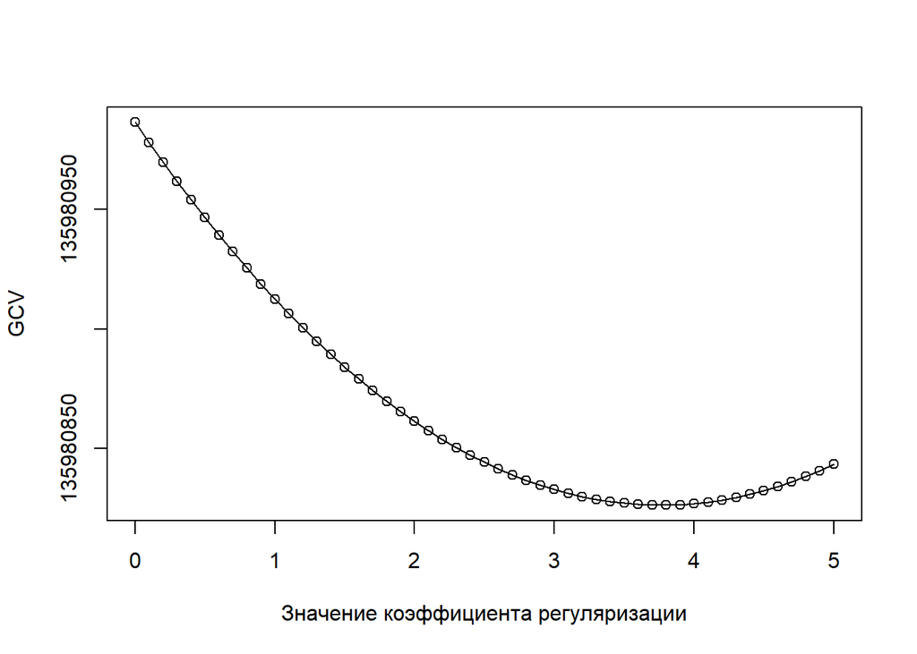

```r
library(MASS)
M1.ridge <- lm.ridge(price ~ repair + year_built_empty + house_age +
                       dist_to_subway + subway_dist_to_center +
                       footage + floor + AO + hm +
                       first_floor + last_floor,
        data = data,
        lambda = seq(0, 5, 0.1))

plot(x = M1.ridge$lambda, y = M1.ridge$GCV, type = "o",
     xlab = "Значение коэффициента регуляризации",
     ylab = "GCV")
```

Оптимальное значение параметра lambda:

```r
lambda <- M1.ridge$GCV[which.min(M1.ridge$GCV)]
lambda
```

```
##       3.8
## 135980826
```

Построим оптимальную модель гребневой регрессии и вычислим стандартную ошибку модели на рассматриваемых данных:

```r
M.ridge <- lm.ridge(price ~ repair + year_built_empty + house_age +
                       dist_to_subway + subway_dist_to_center +
                       footage + floor + AO + hm +
                       first_floor + last_floor,
        data = data,
        lambda = 3.8)

# Коэффициенты модели
beta.M.ridge <- coef(M.ridge)

# количество предикторов
p <- length(beta.M.ridge)
```

Чтобы воспользоваться встроенной функцией predict для построения прогноза гребневой регресии, воспользуемся моделью без регуляризации и заменим ее коэффициенты на коэффициенты модели с регуляризацией:

```r
M_test <- lm(price ~ repair + year_built_empty + house_age + dist_to_subway +
          subway_dist_to_center + footage + floor + AO +
          hm + first_floor + last_floor,
        data = data
          )

M_test$coefficients <- beta.M.ridge

RSS <- sum((data$price - predict(M_test))^2)

# размер обучающей выборки
n <- length(data$price)

# рассчет стандартного отклонения
RSE.ridge <- sqrt(RSS / (n - p - 1))
```

Сравнение стандартных ошибок с регуляризацией и без:

```r
c(RSE.ridge, summary(M1)$sigma)
```

```
## [1] 1286056 1286002
```

Получившиеся модели слабо отличаются в смысле стандартной ошибки.